# Directional Accuracy for Simple Stock Algo

2024-11-03

# Motivation and Problem Statement:

Now that we have a model for prediction, let us test the robustness of the model. We will start with **directional accuracy**. To do so, we will develop a hypothesis test to understand the model’s directional accuracy. Most experts in stock market trading’s directional accuracy hall around 50%. **Note: Directional accuracy is not the only indicator of a good model, nor is it a grantee that a model will perform well in terms of profit.** Therefore, this will be the basis of our hypothesis test.

# Model and Graph

```r
# Create a MSE Funcion:
mse.stock <- function(data){
  return(mean(data$Error^2))
}

# Create Optimized Model:
sample <- c(runif(1,0,350),runif(1,351,1000),runif(1,1001,1500))
left <- sample(sample,1)
right <- round(runif(1,1501,length(ford.df$F.Close)))
print(right - left)
```

```
## [1] 1039.28
```

```r
data <- ford.df$F.Close # Data for Model
ford.original <- simple.algo(data,1,left,right) # Original Model with Omega = 1
omega <- gradient.descent(ford.original) # Calculate Optimized Omega
cat("Omega:",omega)
```

```
## Omega: -0.02677143
```

```r
ford.optimized <- simple.algo(data,omega,left,right) # Optimized Model

# Compare MSE Values:
og.mse <- mse.stock(ford.original)
opt.mse <- mse.stock(ford.optimized)
cat("Origiinal MSE: ",og.mse,
    "\n",
    "Optimized MSE: ",opt.mse)
```

```
## Origiinal MSE:  0.08179478
##  Optimized MSE:  0.03435069
```

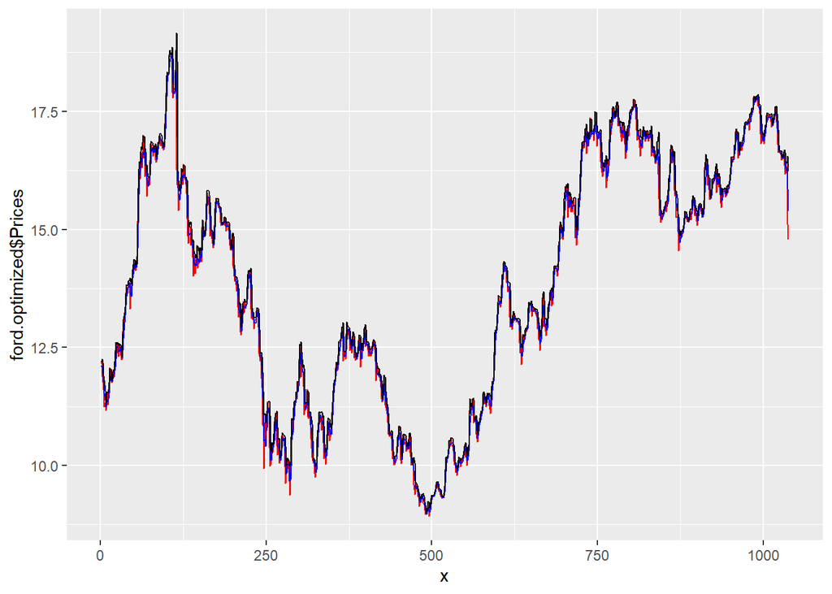

```r
# Graph Models
x = c(1:length(ford.optimized$Prices))
ggplot(data = ford.optimized)+
  geom_line(aes(x=x,y=ford.optimized$Prices),col="red")+
  geom_line(aes(x=x,y=ford.optimized$Func),col="blue")+
  geom_line(aes(x=x,y=ford.original$Func),col="black")
```

# Directional Accuracy Testing: How well does the algorithm detect ups and downs in the price?

We want to test directional accuracy of our model. We do not want this to be too high, as we will over fit. We also do not want this to be too low. Let us observe different window sizes to see where the directional accuracy converges.

```r
direction.comparison <- function(data){
  # Retrieve Data
  prices <- data$Prices
  model <- data$Func

  # Convert to Binary Vectors
  prices.bin <- ifelse(diff(prices) > 0,1,0)
  model.bin <- ifelse(diff(model) > 0,1,0)

  # Discard NA's
  prices.bin <- prices.bin[!is.na(prices.bin)]
  model.bin <- model.bin[!is.na(model.bin)]

  # Check for Congruence:
  check <- ifelse(prices.bin == model.bin,1,0)

  # Accuracy Percentage:
  acc <- sum(check)/length(check)

  return(acc)
}

# For function we need data, iterations
acc.func <- function(data,omega,iterations){

  omega <- omega
  data <- data

  # Initialize Empty Vectors:
  window <- c() # Initialized Window Vector
  accuracy <- c() # Initialized

  iterations <- iterations # For loop iterations

  middle <- round(length(data$Prices)/2) # For runif

  # Loop
  i = 0
  time.a <- proc.time()[3]
  for(i in 1:iterations){
    # 1. Create Bounds:
    left <- round(runif(1,0,middle))
    #print(left)
    right <- round(runif(1,middle+1,length(data$Prices)))
    #print(right)
    #cat(left,right)
    # 2. Create Models:
    model <- simple.algo(data$Prices,omega,left,right)
    #print(2)
    # 3. Run Accuracy Function
    acc <- direction.comparison(model)
    #print(4)
    # 4. Append Vectors
    window <- append(window,right-left)
    accuracy <- append(accuracy,acc)
    #print(5)
  }
    time.b <- proc.time()[3]

    #print(time.b - time.a) # Prints time to complete algorithm
    #print(summary(window)) # Prints range of window

    df <- data.frame(window,accuracy)
    return(df)
}

accuracy.check <- acc.func(ford.optimized,omega,500)
```

# Analysis of Findings

## Graph of Window vs Accuracy

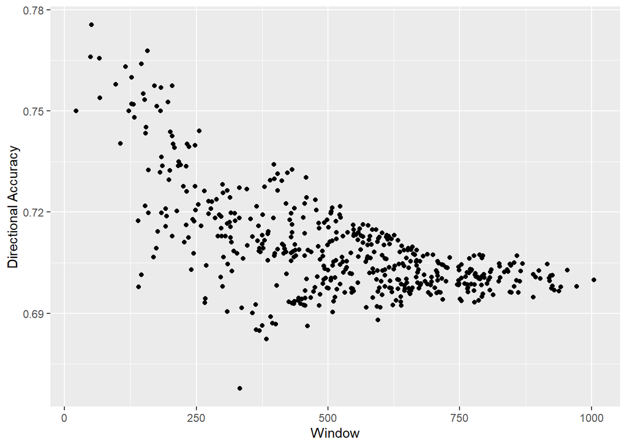

## Hypothesis Testing:

Let us develop a null hypothesis: Since random guessing will yield about 50%, let us set up our null hypothesis of the directional accuracy:

$H_{0}: p \leq 0.5$: The directional accuracy of the model is less than or equal to $0.5$

$H_{a}: p > 0.5$: The directional accuracy of the model is greater than $0.5$

We need our test statistic:

We will use a one sample proportion test, therefore our test statistic will be:
$$Z
=\frac{\hat{p}-p_{0}}{\sqrt{\frac{p_{0}(1-p_{0})}{n}}}$$

```r
# Calculate Accuracy for One Sample:
p.hat.vec <- acc.func(ford.optimized,omega,1)
p.hat <- p.hat.vec$accuracy
p0 <- 0.5
cat("P Hat: ",p.hat,"\n")
```

```
## P Hat:  0.7325581
```

```r
# Calculate Z-Statistic:
z <- (p.hat - p0)/(sqrt((p0*(1-p0))/(length(ford.optimized$Prices))))
cat("Z-Value: ",z,"\n")
```

```
## Z-Value:  14.98512
```

```r
# Calculate p-value
p.value <- pnorm(z,0,1,lower.tail = F)
cat("P-Value: ",p.value,"\n")
```

```
## P-Value:  4.592995e-51
```